# Was immer man unternimmt - Bayerische Staatsoper

[figure not shown]

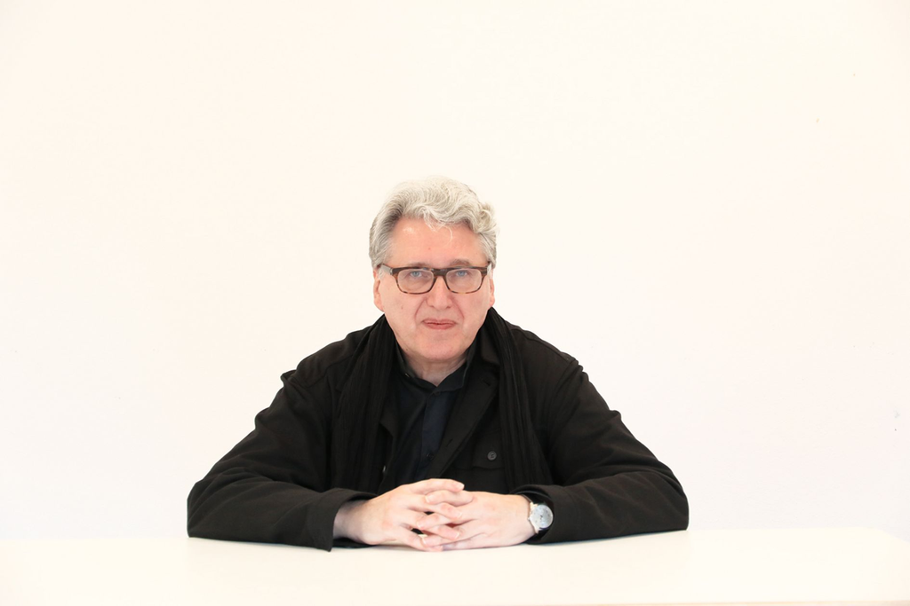

# Was immer man unternimmt

Ein Gespräch mit dem Philosophen Boris Groys über Tolstois Geschichtsauffassung und ihren Einfluss auf die russische Mentalität

DAS GESPRÄCH FÜHRTE MALTE KRASTING  
*Boris Groys, geboren 1947 in Berlin, ist Philosoph, Kunstkritiker, Medientheoretiker, Essayist und international anerkannter Experte für die Kunst und Literatur der Sowjetära, besonders für die Russische Avantgarde. Er studierte Mathematik und Philosophie in Leningrad und gab in den siebziger Jahren illegale Literaturzeitschriften heraus. 1981 verließ er die Sowjetunion. Er lehrte als Gastprofessor unter anderem an der University of Pennsylvania in Philadelphia, an der University of Southern California in Los Angeles und von 1994 an als Professor für Kunstwissenschaft, Philosophie und Medientheorie an der Hochschule für Gestaltung in Karlsruhe. Seit 2005 unterrichtet er als Global Distinguished Professor of Russian and Slavic Studies an der New York University. Zuletzt erschienen von ihm die Bücher Einführung in die Anti-Philosophie (Hanser Verlag), In the Flow (Verso Books), Philosophie der Sorge (Claudius) und Becoming an Artwork (Polity).*

> Tolstois Erlebnisse im Krimkrieg 1856, jenem Krieg, in dem die Russen gegen das vereinte Europa kämpften, haben bei ihm zu einer totalen Ablehnung von Kriegsideologie und Gewalt geführt

*Welche Rolle spielt Lew Tolstoi heute im russischen Geistesleben?*

Tolstoi ist einerseits eine zentrale Figur in der russischen Kultur, seine Romane werden in den Schulen gelesen, sein Werk ist sozusagen Basiswissen, vom Anfang des 20. Jahrhunderts über die sowjetische Zeit bis jetzt. Es gehört zu den Grundlagen der Bildung. Andererseits ist er als Persönlichkeit eine komplexe Erscheinung. In seinem späten Schaffen war Tolstoi überzeugter Pazifist. Er hat einige Jahre vor seinem Tod alle seine Romane verdammt, weil er sie für zu „weltlich“ hielt. Er hat eine eigene Religion protestantischen Typus’ entwickelt, auf der Grundlage des radikalen Pazifismus. Er missbilligte die Armee generell und hat sogar dazu aufgerufen, den Kriegsdienst zu verweigern. Aber das war die letzte Periode seines Lebens. Ursprünglich war er selbst Offizier, kämpfte etwa drei Jahre lang im Kaukasuskrieg – in Tschetschenien – und hat darüber eine brillante Erzählung geschrieben: *Hadschi Murat.* Dieser Erfahrungsbericht ist voller Bewunderung für das tschetschenische Volk; in ihm wird der Titelheld, ein muslimischer Tschetschene, zur Verkörperung des Humanismus. Tolstois Erlebnisse im Krimkrieg 1856 gegen die Engländer und Franzosen, jenem Krieg, in dem die Russen gegen das vereinte Europa kämpften, haben dann bei ihm zu einer totalen Ablehnung von Kriegsideologie und Gewalt geführt, wie es oft passiert mit Menschen, die tatsächlich selbst im Krieg waren. In *Krieg und Frieden* hat Tolstoi daraufhin Napoleon sehr kritisch als jemanden dargestellt, der an den Krieg glaubt, an Heroismus, an Eroberung; ihm gegenübergestellt ist auf russischer Seite der einfache Soldat Platon Karatajew, der den Krieg und jede Form von Gewalt ablehnt. Die übrigen Hauptpersonen des Romans sind am Ende absorbiert von alltäglichen Vorgängen – was Tolstoi als etwas Erstrebenswertes schildert: Der Schluss des Buches ist eine Panegyrik auf das einfache Familienleben. Das Buch ist also die Geschichte davon, wie ein Eroberer nach Russland kommt, das eigentlich keinen Krieg wünscht und im Grunde gar nicht kämpfen will, und dann in diesem ungeheuren Territorium versinkt, in einer Masse untergeht, die diesen Kriegshelden durch passiven Widerstand dazu bringt, sich selbst zu demontieren. Selbst General Kutusow will keine aktiven Kriegshandlungen.

Ein zweites Beispiel mit derselben Formel ist Fjodor Dostojewskis Roman *Schuld und Sühne.* Raskolnikow will sozusagen ein neuer Napoleon sein, er wiederholt dieselben Verhaltensmuster und scheitert schließlich – nicht, weil er Gegengewalt erfährt, sondern weil seine Tat in sich selbst kollabiert und er ins Nichts versinkt. Das ist eine typische Einstellung der russischen Literatur in Bezug auf Napoleon und seinen Russland-Feldzug.

> Tolstoi meint, dass sich der Gang der Geschichte generell nicht verändern lässt. Diese Überzeugung ist tief in der russischen Geistesgeschichte verankert

*Hat Tolstois Geschichtstheorie, mit der er eine Abkehr von der Heldenverehrung propagierte, die russische Philosophie geprägt?*

Man kann das so sehen. Der Fehler Napoleons war ja nicht, dass er kein guter Stratege war, sondern dass er Gewalt als Mittel zur Weltveränderung gesehen hat. Napoleon war für weite Teile der russischen Gesellschaft ein Symbol für Revolution, für eine gewaltsame Veränderung des üblichen Ganges der Dinge. In der Tat war Napoleon unbestreitbar ein Produkt der Französischen Revolution, des Glaubens daran, dass man mit Gewalt – als einzelner oder als Gruppe – die Welt verändern kann. Tolstoi zeigt dagegen, dass Gewalt, die von einer kleinen Gruppe ausgeht, in der Welt untergeht, also nicht fähig ist, die Welt zu verändern. Er artikuliert nicht nur Zweifel an der Revolution, sondern weist den Gedanken grundsätzlich zurück, er äußert einen Unglauben an die Revolution, könnte man sagen, einen Unglauben an die Gewalt als Motor der Geschichte. Man darf nicht vergessen, dass Russland philosophisch von Hegel beeinflusst war. Hegel sah in der Französischen Revolution und besonders in der Figur von Napoleon den Höhepunkt der Geschichte. In Russland wurde die Idee, dass Gewalt die Welt verändern kann, als spezifisch westlicher Glaube an die Möglichkeit aktiver Intervention in den Gang der Geschichte aufgefasst. Tolstoi jedoch meint, dass sich der Gang der Geschichte, der Gang des Lebens generell nicht verändern lässt. Keine Anstrengung könne da etwas ausrichten. Diese Überzeugung ist tief in der russischen Geistesgeschichte verankert. Man hatte immer das Gefühl: Was immer man unternimmt, es kommt auf dasselbe heraus. Und Napoleon war Beispiel für jemanden, der sich sehr angestrengt hat, um in den Gang der Dinge einzugreifen. So sind wie *Krieg und Frieden* und *Schuld und Sühne* auch viele andere Romane und Essays dieser Zeit zu verstehen. In dieser Überzeugung kommt gewissermaßen das asiatische, das chinesische Element im Russischen zum Vorschein: der Glaube daran, dass weder durch Krieg noch durch Technologie, nicht durch irgendwelche Willensanstrengung der Weltenlauf aus der Fassung zu bringen ist.

> Man hatte immer das Gefühl: Was immer man unternimmt, es kommt auf dasselbe heraus.

*Wie konnte Prokofjew diesen Roman als Grundlage einer Oper verwenden, mit der die Rote Armee und ihr Sieg im „Großen Vaterländischen Krieg“ gefeiert werden sollte?*

Weil man Hitler als neuen Napoleon verstanden hat: als Produkt einer Revolution. Nicht zufälligerweise hat Leni Riefenstahl ihren Film *Triumph des Willens* genannt. Hitler hat man in Russland auf ähnliche Weise gesehen wie früher Napoleon, als jemanden, der so etwas wie einen Willenstriumph manifestieren will, der durch Gewaltanwendung die Geschichte verändern will. Der Einmarsch von 1941 wurde als Wiederholung des Napoleonischen Feldzugs betrachtet, als zweiter Versuch aus dem Westen, Russland und somit auch die Weltgeschichte gewaltsam zu verändern, und die Idee hinter dieser Oper wie hinter vielen anderen künstlerischen Werken damals war, dass Hitler mit seinem „Triumph des Willens“ sich genauso im Nichts auflösen und versinken werde – weil dieses Schicksal eben jeden ereilt, der so etwas versucht. Das war früher so und wird auch jetzt so sein.

> Man hatte festgestellt, dass der Kommunismus als Idee allein nicht ausreicht, um die russische Bevölkerung im Ganzen zu mobilisieren. Dafür brauchte man den Nationalismus.

*Prokofjew musste die Konzeption seiner Oper tiefgreifend ändern, aus der Kulturpolitik wurde der Wunsch an ihn herangetragen, aus dem eigentlich fast lethargischen General Kutusow eine Stalin-Figur zu formen. In welchem Kontext ist das zu sehen?*

Diese Tendenz entstand erst ganz kurz vor dem Krieg; vorher wurde in der sowjetischen Kunst etwas ganz Anderes angestrebt. Die kommunistische Partei war zunächst gegen die Glorifizierung des Militärs, gegen das Herausheben einzelner Führungsfiguren. Sie wollte, im Gegenteil, die Bedeutung der Masse, der ausgebeuteten Klassen, von Proletariat und Bauerntum hervorheben – und diese Gruppen sollten eine besondere Rolle in den Werken der Literatur, in Musik und Theater spielen. Über große Gestalten zu schreiben war verpönt und eigentlich verboten. Die Wende kam, als Stalin beschloss, die russische Geschichte und den russischen Nationalismus für den Krieg zu mobilisieren. Erste Vorläufer davon sind um 1934 zu beobachten, als Reaktion auf die Machtergreifung der Nationalsozialisten im Jahr davor; in dieser Situation begann die offizielle Ideologie allmählich, in Opposition zum Faschismus – der damals im genannten Sinne als „revolutionäre“ Kraft aufgefasst wurde, im Gegensatz zum Kommunismus – andere, zusätzliche Motive zu aktivieren. Es gab damals einen Paradigmenwechsel in der Geschichtsschreibung: Historische Herrscher wie Iwan der Schreckliche und Peter der Große wurden wieder positiv dargestellt. Dieser Anschluss an die großen Figuren der russischen Geschichte wurde später, praktisch mit dem Krieg, noch verstärkt. Das Verhältnis zwischen Russland und Deutschland war kompliziert; wenn man also wie Prokofjew aus Tolstois Krieg und Frieden eine Oper erarbeiten wollte, musste man auf die richtige Konstellation warten. Die war im Grunde erst mit dem deutschen Angriff gegeben. Und erst nach dem Krieg, in den fünfziger Jahren, kam die Glorifizierung der russischen Vergangenheit richtig zum Blühen. Orden und Uniformen wurden nach und nach wieder en vogue. Man hatte festgestellt, dass der Kommunismus als Idee allein nicht ausreicht, um die russische Bevölkerung im Ganzen zu mobilisieren. Dafür brauchte man den Nationalismus.

> Man muss diese Oper verstehen als ein Werk, in dem gezeigt wird, wie ein Volk gegen einen Aggressionskrieg reagiert.

*Ist dieser Mechanismus im Vorfeld des Kriegs gegen die Ukraine aufs Neue eingesetzt worden?*

Es ist schwer zu sagen, was heute geschieht. In ideologischer Hinsicht ist die derzeitige russische Regierung nicht so sattelfest wie die sowjetische. Die sowjetische Führung war komplett involviert in den ideologischen, post-hegelianischen historischen Diskurs. Sie alle glaubten an die Transformation von Quantität in Qualität und an die Negation der Negation. Die heutigen Machthaber sind nicht so *sophisticated.* Das ist Punkt eins.

Punkt zwei ist, dass sich aus vielen komplizierten historischen Gründen – und dazu hat auch der Westen beigetragen – in der Zeit zwischen 1991 und jetzt in Russland einiges in der Einschätzung gewandelt hat, was am Ende des Sozialismus vorgegangen ist. Damals, in den Jahren 1989 bis 1991, war die herrschende Meinung: Das demokratische Russland hat sich erfolgreich im Kampf gegen ein autoritäres Regime behauptet. Das war zwar ein Irrtum, denn der Umsturz war in Wahrheit keine Bewegung von unten, sondern von oben gesteuert; die „Revolution“ ging auf Beschlüsse des Politbüros innerhalb der offiziellen Strukturen zurück. Das war aber irrelevant für das Selbstbewusstsein in der Bevölkerung und ihren Stolz auf die Befreiung vom Kommunismus aus eigener Kraft.

Heute lautet die herrschende Meinung: Der Westen hat den Kalten Krieg gewonnen. Das ist eine einschneidende Veränderung der Optik. Die westliche Auffassung dessen, was in Russland passiert ist, hat dabei eine wesentliche Rolle gespielt. Die Russen haben lange Zeit an ihre eigene demokratische Revolution geglaubt. Aber je mehr sie nichtrussische Darstellungen dieses Umbruchs gelesen haben, je mehr sie in den Westen gereist sind und dabei allmählich erfahren mussten, dass man im Westen einen Sieg über Russland errungen zu haben meint, hat sich ihre Perspektive verändert. Denn wenn der Fall des kommunistischen Regimes ein Sieg des Westens war und nicht, wie anfangs vermeint, ein selbst zustande gebrachter Systemwechsel, dann muss dagegen etwas unternommen werden. Was das sein soll, das war und bleibt den Menschen unklar. Wladimir Putin hat diese Leerstelle genutzt, um dem russischen Volk eine mögliche Maßnahme vorzuschlagen. Zwar genießt sein Feldzug gegen die Ukraine keine große Popularität in Russland. Gleichzeitig aber nutzt er das verbreitete Gefühl, dass Russland im Westen als der Verlierer einer quasi-militärischen Auseinandersetzung betrachtet wird. Das irritiert die Menschen und produziert ein antiwestliches Ressentiment, das es früher nicht gegeben hat. Dieses Ressentiment übersetzt sich nicht unbedingt in eine kriegerische Begeisterung, aber die psychologische Atmosphäre erlaubt es dem heutigen Regime, so zu handeln, wie wir es erleben.

Man muss diese Oper daher verstehen als ein Werk, in dem gezeigt wird, wie ein Volk gegen einen Aggressionskrieg reagiert. In der Handlung von Buch und Oper geht es um den Angriff Napoleons auf Russland, auf den die überfallene Seite mit halbpassivem Widerstand reagiert. Russland hatte keine aggressive Szene in diesem Krieg, für Russland war es ein reiner Verteidigungskrieg.

*Liegt eine Utopie in der Geschichte?*

Tolstoi war Anti-Utopist! Utopien sind nach seiner Überzeugung etwas, das den Leuten aufoktroyiert wird. Er glaubte, dass die Menschen geboren werden, leben und sterben – sonst sei darüber nichts zu sagen. Wenn man mehr darüber sagt, dann irrt man. Er hat bloß viele tausend Seiten dazu gebraucht, dieser Idee Ausdruck zu verleihen.

# Krieg und Frieden (Woina i mir)

# Hintergründe zum Stück

[interactive chart not shown]